# Practical 2 Repeated Measurements

## Practical 2: Mixed Effects Models for Continuous Data

We start by loading the packages we will need for this practical and the data from [GitHub](https://github.com/drizopoulos/Repeated_Measurements). This is achieved with the following commands:

```r
# packages
library("lattice")
library("nlme")
library("splines")

# data
con <- url("https://raw.github.com/drizopoulos/Repeated_Measurements/master/Data.RData")
load(con)
close(con)
```

### Question 1

The following piece of code extracts the number of repeated measurements per patient:

```r
length.no.NA <- function (x) sum(!is.na(x))
ns <- with(pbc2, tapply(prothrombin, id, length.no.NA))
```

And we produce numerical summaries and a visualization using a boxplot:

```r
c(summary(ns), sd = sd(ns))
```

```
##      Min.   1st Qu.    Median      Mean   3rd Qu.      Max.        sd
##  1.000000  3.000000  5.000000  6.233974  9.000000 16.000000  3.774990
```

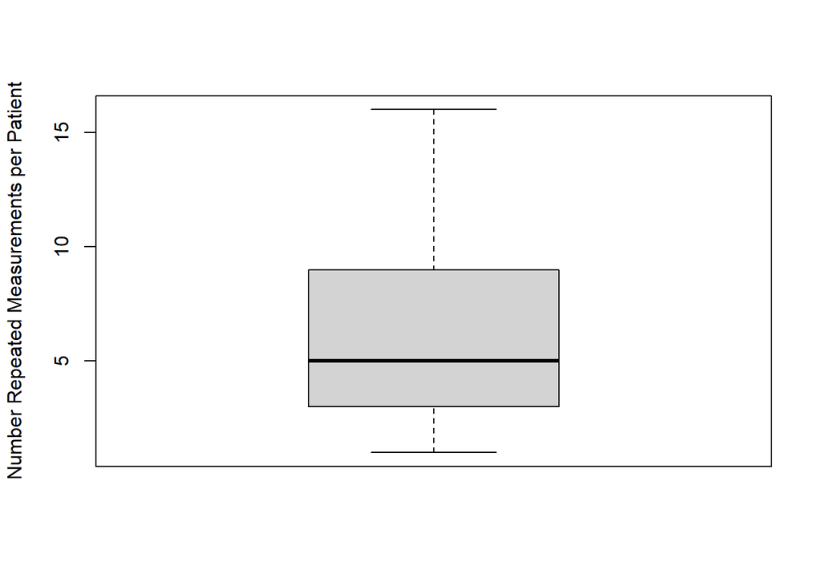

```r
boxplot(ns, col = "lightgrey", ylab = "Number Repeated Measurements per Patient")
```

The median number of repeated measurements per individual is five, and only 25% of the patients have less than three measurements. Hence, we have sufficient information to model potential nonlinearities in the subject-specific trajectories.

### Question 2

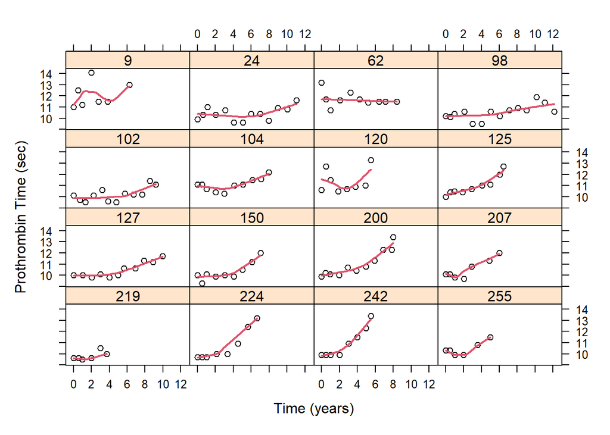

```r
set.seed(123)
ids <- sample(names(ns)[ns >= 6], 16)
xyplot(prothrombin ~ year | id,
       panel = function (x, y, ...) {
           panel.xyplot(x, y, type = "p", col = 1, ...)
           panel.loess(x, y, col = 2, lwd = 2, span = 0.8)
       }, data = pbc2, subset = id %in% ids, layout = c(4, 4), as.table = TRUE,
       xlab = "Time (years)", ylab = "Prothrombin Time (sec)")
```

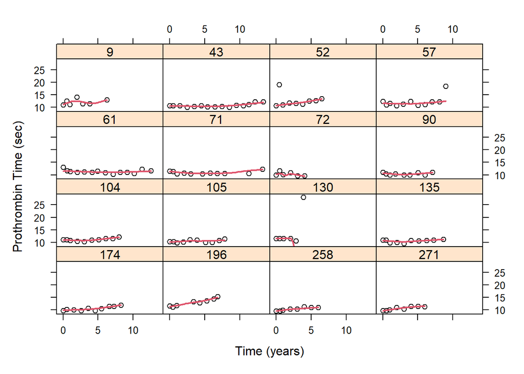

```r
set.seed(321)
ids <- sample(names(ns)[ns >= 6], 16)
xyplot(prothrombin ~ year | id,
       panel = function (x, y, ...) {
           panel.xyplot(x, y, type = "p", col = 1, ...)
           panel.loess(x, y, col = 2, lwd = 2, span = 0.8)
       }, data = pbc2, subset = id %in% ids, layout = c(4, 4), as.table = TRUE,
       xlab = "Time (years)", ylab = "Prothrombin Time (sec)")
```

### Question 3

To fit the linear mixed effects model we use function [lme()](https://goo.gl/4fngXl). The basic call to this function requires to specify argument `fixed` which is a formula providing the fixed-effects structure, argument `random` which is a formula providing the random-effects structure, and `data` the data frame that contains the variables we need. Hence, the call to [lme()](https://goo.gl/4fngXl) to fit the mixed for prothrombin time with

- fixed effects: linear and quadratic time evolutions, the nonlinear effect of age using natural cubic splines with 3 degrees of freedom, the main effects of sex and drug, and the interactions of time with sex and drug, and age with sex and drug, and
- random effects: random intercepts

is:

```r
fm_1 <- lme(prothrombin ~ (year + I(year^2)) * (sex + drug) + ns(age, 3) +
                ns(age, 3) : (sex + drug), data = pbc2,
            random = ~ 1 | id, subset = prothrombin < 18)
```

Note that we use the `subset` argument to exclude the prothrombin times which are larger than 18 sec.

### Question 4

We will start expanding the random-effects structure, while keeping the same fixed effects, in order to appropriately model the correlations in the repeated prothrombin time measurements. We start by including the linear random slopes term; note that instead of calling [lme()](https://goo.gl/4fngXl) again and having to specify all arguments, we just use function `update()`:

```r
fm_2 <- update(fm_1, random = ~ year | id)
```

To test whether the random slopes terms improves the fit of the model we perform the likelihood ratio test using the [anova()](https://goo.gl/88h4GZ) function:

```r
anova(fm_1, fm_2)
```

```
##      Model df      AIC      BIC    logLik   Test L.Ratio p-value
## fm_1     1 20 5037.294 5148.433 -2498.647
## fm_2     2 22 4700.165 4822.418 -2328.082 1 vs 2 341.129  <.0001
```

The results suggest that this term significantly improves the fit. We continue by including the quadratic random slopes term, i.e.,

```r
fm_3 <- update(fm_1, random = ~ year + I(year^2) | id)
```

Again we test using the likelihood ratio test:

```r
anova(fm_2, fm_3)
```

```
##      Model df      AIC      BIC    logLik   Test  L.Ratio p-value
## fm_2     1 22 4700.165 4822.418 -2328.082
## fm_3     2 25 4691.198 4830.122 -2320.599 1 vs 2 14.96652  0.0018
```

The fit improves again significantly. We continue by adding the cubic random slopes term, i.e.,

```r
fm_4 <- update(fm_1, random = ~ year + I(year^2) + I(year^3) | id)
```

And we test again using likelihood ratio test:

```r
anova(fm_3, fm_4)
```

```
##      Model df      AIC      BIC    logLik   Test      L.Ratio p-value
## fm_3     1 25 4691.198 4830.122 -2320.599
## fm_4     2 29 4699.198 4860.350 -2320.599 1 vs 2 2.010529e-08       1
```

From this last test we obtain virtually the same likelihood value, and a p-value almost equal to 1. Hence, the cubic random slopes term does not seem to further improve the fit, and therefore we will continue with model `fm_3`.

### Question 5

Having chosen the random-effects structure we turn now in the fixed effects. We will first test whether the interaction terms have an important contribution in the fit of the model. Due to the fact that we have also interaction of the time variable with baseline covariates (i.e., sex and drug) we cannot compute the F-test because the denominator degrees of freedom cannot be (reliably) defined. To this end, we will perform a likelihood ratio test. Remember, as we have seen in **Practical 1**, to perform a likelihood ratio test we need to fit the model under maximum likelihood (and not the restricted maximum likelihood-the default in [lme()](https://goo.gl/4fngXl)). Thus, in the following piece of code we first re-fit model `fm_3` using maximum likelihood and then we fit the model that excludes the interaction terms (note that we efficiently use function `update()` again):

```r
fm_3ML <- update(fm_3, method = "ML")
fm_3ML_noInt <- update(fm_3ML, fixed = . ~ year + I(year^2) + sex + drug + ns(age, 3))
```

Then we can compare the two models using the [anova()](https://goo.gl/88h4GZ) function:

```r
anova(fm_3ML_noInt, fm_3ML)
```

```
##              Model df      AIC      BIC    logLik   Test  L.Ratio p-value
## fm_3ML_noInt     1 15 4631.136 4714.631 -2300.568
## fm_3ML           2 25 4646.194 4785.352 -2298.097 1 vs 2 4.942272   0.895
```

The results suggest that the effects of time and age on the prothrombin time do not differ between males and females, and between treated and non-treated patients.

### Question 6

We continue by testing the nonlinear terms. Similarly to what we did for the interaction terms, we first perform the omnibus test for all the nonlinear terms in the model. As a initial step we need to fit the model that excludes all nonlinear terms, i.e.,

```r
fm_3ML_noInt_AllLin <- update(fm_3ML, fixed = . ~ year + sex + drug + age)
```

Then we test using [anova()](https://goo.gl/88h4GZ) function:

```r
anova(fm_3ML_noInt_AllLin, fm_3ML_noInt)
```

```
##                     Model df      AIC      BIC    logLik   Test  L.Ratio
## fm_3ML_noInt_AllLin     1 12 4651.012 4717.807 -2313.506
## fm_3ML_noInt            2 15 4631.136 4714.631 -2300.568 1 vs 2 25.87551
##                     p-value
## fm_3ML_noInt_AllLin
## fm_3ML_noInt         <.0001
```

We have found a significant difference between the two models, meaning that some of the nonlinear terms have an important contribution to the model. We will proceed to find which nonlinear terms we need. First, we are going to test the quadratic term for the time effect. To do this, we fit the model under the corresponding null hypothesis (i.e., we drop the quadratic term for time but we keep the nonlinear terms for age):

```r
fm_3ML_noInt_LinTime <- update(fm_3ML, fixed = . ~ year + sex + drug + ns(age, 3))
```

The corresponding likelihood ratio test gives:

```r
anova(fm_3ML_noInt_LinTime, fm_3ML_noInt)
```

```
##                      Model df      AIC      BIC    logLik   Test  L.Ratio
## fm_3ML_noInt_LinTime     1 14 4654.641 4732.569 -2313.320
## fm_3ML_noInt             2 15 4631.136 4714.631 -2300.568 1 vs 2 25.50502
##                      p-value
## fm_3ML_noInt_LinTime
## fm_3ML_noInt          <.0001
```

The result is significant implying the quadratic term is required. We continue by testing the nonlinear age effect, by fitting the model under the corresponding null hypothesis (i.e., we now keep the quadratic term for time and we drop the nonlinear terms for age):

```r
fm_3ML_noInt_LinAge <- update(fm_3ML, fixed = . ~ year + I(year^2) + sex + drug + age)
```

The corresponding likelihood ratio test gives:

```r
anova(fm_3ML_noInt_LinAge, fm_3ML_noInt)
```

```
##                     Model df      AIC      BIC    logLik   Test   L.Ratio
## fm_3ML_noInt_LinAge     1 13 4627.405 4699.767 -2300.702
## fm_3ML_noInt            2 15 4631.136 4714.631 -2300.568 1 vs 2 0.2688104
##                     p-value
## fm_3ML_noInt_LinAge
## fm_3ML_noInt         0.8742
```

We have not found a significant difference between the two models, which means that we did not find any support from the data for a nonlinear age effect. Hence, we are going to continue using model `fm_3ML_noInt_LinAge`.

### Question 7

Using the [summary()](https://goo.gl/u69ACN) function we obtain a detailed output of our final model `fm_3ML_noInt_LinAge`:

```r
summary(fm_3ML_noInt_LinAge)
```

```
## Linear mixed-effects model fit by maximum likelihood
##   Data: pbc2
##   Subset: prothrombin < 18
##        AIC      BIC    logLik
##   4627.405 4699.767 -2300.702
##
## Random effects:
##  Formula: ~year + I(year^2) | id
##  Structure: General positive-definite, Log-Cholesky parametrization
##             StdDev     Corr
## (Intercept) 0.75618252 (Intr) year
## year        0.33602026 -0.272
## I(year^2)   0.01944211  0.044 -0.839
## Residual    0.59259234
##
## Fixed effects:  prothrombin ~ year + I(year^2) + sex + drug + age
##                   Value  Std.Error   DF  t-value p-value
## (Intercept)   10.424750 0.28058606 1618 37.15349  0.0000
## year           0.063260 0.02768266 1618  2.28519  0.0224
## I(year^2)      0.018955 0.00247593 1618  7.65560  0.0000
## sexfemale     -0.293693 0.14429649  308 -2.03534  0.0427
## drugD-penicil -0.171357 0.09130331  308 -1.87678  0.0615
## age            0.012408 0.00443887  308  2.79528  0.0055
##  Correlation:
##               (Intr) year   I(y^2) sexfml drgD-p
## year          -0.081
## I(year^2)      0.038 -0.787
## sexfemale     -0.616  0.004  0.003
## drugD-penicil -0.069 -0.003 -0.001  0.029
## age           -0.857  0.013  0.001  0.197 -0.136
##
## Standardized Within-Group Residuals:
##         Min          Q1         Med          Q3         Max
## -3.06935629 -0.52171277 -0.07951942  0.41644562  9.49461936
##
## Number of Observations: 1932
## Number of Groups: 312
```

The interpretation of the regression coefficients is as follows:

- The coefficients that involve the polynomial terms of time do not have a straightforward interpretation - in this cases an Effect Plot is more effective in communicating the results of the model (see Question 9).
- The coefficients of drug, sex and age can be interpreted in a easier manner, namely
  - -0.17 is the expected difference in prothrombin time between treated and placebo patients of the same age and sex, and who are compared at the same follow-up time.
  - -0.29 is the expected difference in prothrombin time females and males, who receive the same treatment are of the same age, and who are compared at the same follow-up time.
  - 0.01 is the expected difference in prothrombin time for a unit increase in the baseline age for patients who have the same sex, received the same treatment, and who are compared at the same follow-up time.

The estimated random effects covariance matrix and the induced correlation matrix are:

```r
getVarCov(fm_3ML_noInt_LinAge, individuals = 271)
```

```
## Random effects variance covariance matrix
##             (Intercept)       year   I(year^2)
## (Intercept)  0.57181000 -0.0691550  0.00064494
## year        -0.06915500  0.1129100 -0.00547980
## I(year^2)    0.00064494 -0.0054798  0.00037800
##   Standard Deviations: 0.75618 0.33602 0.019442
```

```r
cov2cor(getVarCov(fm_3ML_noInt_LinAge, individuals = 271))
```

```
## Random effects variance covariance matrix
##             (Intercept)     year I(year^2)
## (Intercept)    1.000000 -0.27217  0.043868
## year          -0.272170  1.00000 -0.838800
## I(year^2)      0.043868 -0.83880  1.000000
##   Standard Deviations: 1 1 1
```

The estimated marginal covariance matrix and the induced correlation matrix are:

```r
getVarCov(fm_3ML_noInt_LinAge, individuals = 271, type = "marginal")
```

```
## id 271
## Marginal variance covariance matrix
##         1       2       3       4       5       6       7       8
## 1 0.92298 0.53676 0.50483 0.43653 0.36706 0.30253 0.23842 0.18000
## 2 0.53676 0.88074 0.52202 0.50256 0.47790 0.45031 0.41818 0.38453
## 3 0.50483 0.52202 0.88700 0.55925 0.57405 0.57916 0.57547 0.56403
## 4 0.43653 0.50256 0.55925 1.02020 0.76377 0.83559 0.89051 0.92541
## 5 0.36706 0.47790 0.57405 0.76377 1.28440 1.06820 1.17950 1.25980
## 6 0.30253 0.45031 0.57916 0.83559 1.06820 1.60850 1.41770 1.53860
## 7 0.23842 0.41818 0.57547 0.89051 1.17950 1.41770 1.97490 1.78320
## 8 0.18000 0.38453 0.56403 0.92541 1.25980 1.53860 1.78320 2.32750
##   Standard Deviations: 0.96072 0.93848 0.94181 1.01 1.1333 1.2683 1.4053 1.5256
```

```r
cov2cor(getVarCov(fm_3ML_noInt_LinAge, individuals = 271, type = "marginal")[[1]])
```

```
##           1         2         3         4         5         6         7
## 1 1.0000000 0.5953368 0.5579428 0.4498669 0.3371236 0.2482909 0.1765941
## 2 0.5953368 1.0000000 0.5906151 0.5301866 0.4493203 0.3783436 0.3170800
## 3 0.5579428 0.5906151 1.0000000 0.5879028 0.5378169 0.4848786 0.4348056
## 4 0.4498669 0.5301866 0.5879028 1.0000000 0.6672167 0.6523051 0.6273834
## 5 0.3371236 0.4493203 0.5378169 0.6672167 1.0000000 0.7431931 0.7405582
## 6 0.2482909 0.3783436 0.4848786 0.6523051 0.7431931 1.0000000 0.7954379
## 7 0.1765941 0.3170800 0.4348056 0.6273834 0.7405582 0.7954379 1.0000000
## 8 0.1228126 0.2685729 0.3925547 0.6005569 0.7286124 0.7951803 0.8317333
##           8
## 1 0.1228126
## 2 0.2685729
## 3 0.3925547
## 4 0.6005569
## 5 0.7286124
## 6 0.7951803
## 7 0.8317333
## 8 1.0000000
```

### Question 8

To compare the marginal and subject-specific predictions from model `fm_3ML_noInt_LinAge` we will use function [fitted()](https://goo.gl/cCuO4T). Argument `level` of this function specifies the type of fitted values we obtain. The relevant calls are (first we define the version of the dataset the excludes the outliers):

```r
pbc2n <- pbc2[pbc2$prothrombin < 18, ]
pbc2n$fitted_marg <- fitted(fm_3ML_noInt_LinAge, level = 0) # marginal
pbc2n$fitted_subj <- fitted(fm_3ML_noInt_LinAge, level = 1) # subject-specific
```

Then we create the plot using a similar call to function [xyplot()](https://goo.gl/KhfGGL) as in Section 3.4:

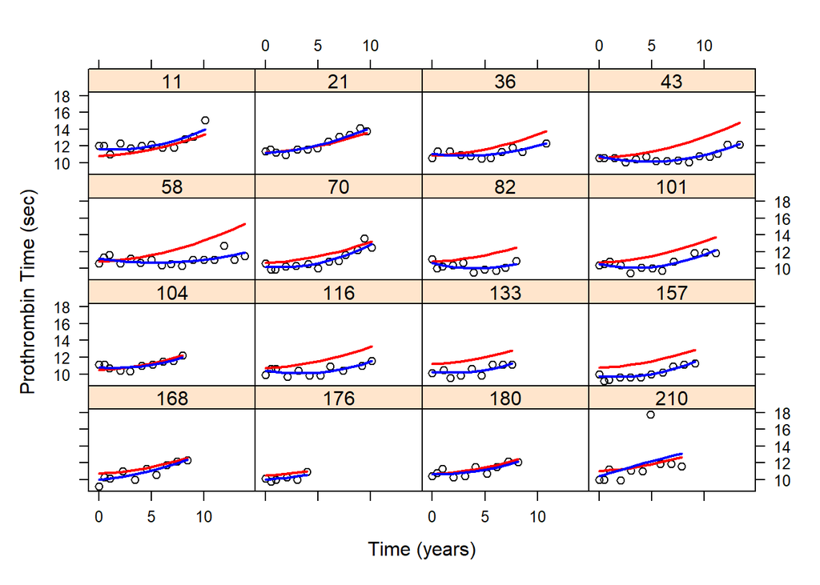

```r
ids <- c(133, 36, 180, 11, 168, 116, 70, 58, 82, 104,
         43, 21, 101, 210, 176, 157)
xyplot(prothrombin + fitted_marg + fitted_subj ~ year | id, data = pbc2n,
       panel = function (x, y, ...) {
           x.mat <- matrix(x, ncol = 3)
           y.mat <- matrix(y, ncol = 3)
           panel.xyplot(x.mat[, 1], y.mat[, 1], type = "p", col = "black")
           panel.xyplot(x.mat[, 2], y.mat[, 2], type = "l", lwd = 2, col = "red")
           panel.xyplot(x.mat[, 3], y.mat[, 3], type = "l", lwd = 2, col = "blue")
       }, subset = id %in% ids, layout = c(4, 4), as.table = TRUE,
       xlab = "Time (years)", ylab = "Prothrombin Time (sec)")
```

As we have seen in Section 3.4, also here we observe that the subject-specific predictions are much closer to the actual data of each subject than the corresponding marginal predictions.

### Question 9

To create the effect plot we first need to define the function `effectPlotData()` which we have introduced in Section 3.2. This function takes a fitted mixed model, the data frame `newdata` based on which the plot will be made, and the original data we used to fit the model, and returns the predictions for each row of `newdata` with the corresponding lower and upper limits of the 95% confidence intervals.

```r
effectPlotData <- function (object, newdata, orig_data) {
    form <- formula(object)
    namesVars <- all.vars(form)
    betas <- if (!inherits(object, "lme")) coef(object) else fixef(object)
    V <- if (inherits(object, "geeglm")) object$geese$vbeta else vcov(object)
    orig_data <- orig_data[complete.cases(orig_data[namesVars]), ]
    Terms <- delete.response(terms(form))
    mfX <- model.frame(Terms, data = orig_data)
    Terms_new <- attr(mfX, "terms")
    mfX_new <- model.frame(Terms_new, newdata, xlev = .getXlevels(Terms, mfX))
    X <- model.matrix(Terms_new, mfX_new)
    pred <- c(X %*% betas)
    ses <- sqrt(diag(X %*% V %*% t(X)))
    newdata$pred <- pred
    newdata$low <- pred - 1.96 * ses
    newdata$upp <- pred + 1.96 * ses
    newdata
}
```

Next we define the data frame with the combination of values of the covariates for which we would like to create the plot. In our example, we set a regular sequence of 25 values from 0 to 12 for the time variable, the levels of the sex variable, and the levels of the drug variable:

```r
newDF <- with(pbc2n, expand.grid(year = seq(0, 12, length.out = 25),
                                sex = levels(sex), drug = levels(drug)))
```

As requested in this Question, we need to set the age variable in the corresponding median of the four groups (i.e., males in placebo, females in placebo, males in active treatment & females in active treatment) from the original dataset. This is achieved with the following piece of code:

```r
pbc2n.id <- pbc2n[!duplicated(pbc2n$id), ]
median_age <- with(pbc2n.id, tapply(age, list(sex, drug), median))
ns <- with(newDF, tapply(year, list(sex, drug), length))
newDF$age <- rep(c(median_age), c(ns))
```

The first line defines the version of the dataset that contains a single row per patient (if we would calculate the median age in each group in the original dataset we would not obtain a correct result because patients have different numbers of repeated measurements). The second line computes the median age in each of the four groups. The third line computes the number of rows that correspond to each of the four groups in the data frame `newDF`. The final line puts the median ages in the corresponding rows. The effect plot is created with the following call to [xyplot()](https://goo.gl/KhfGGL):

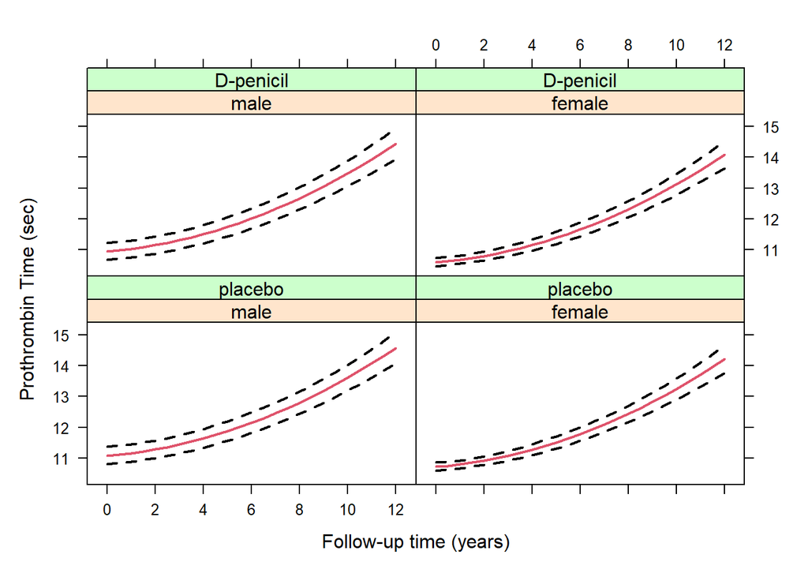

```r
xyplot(pred + low + upp ~ year | sex * drug,
       data = effectPlotData(fm_3ML_noInt_LinAge, newDF, pbc2n),
       lty = c(1, 2, 2), col = c(2, 1, 1), lwd = 2, type = "l",
       xlab = "Follow-up time (years)",
       ylab = "Prothrombin Time (sec)")
```

### Question 10

To investigate whether the assumption for the residuals terms are satisfied we can inspect the scatterplots of the residuals versus the fitted values. As we have seen in Section 3.11, there are two types of residuals we can compute in mixed models, namely the *marginal residuals* and the *conditional residuals*. We start with the standardized conditional residuals and we produce the overall scatteplot of these residuals versus the fitted values, and then we split per sex and treatment allocation:

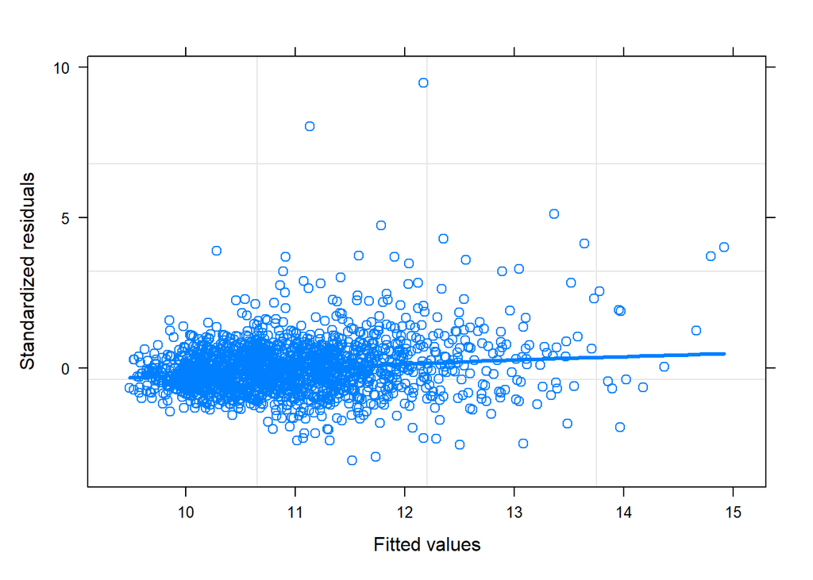

```r
plot(fm_3ML_noInt_LinAge, resid(., type = "p") ~ fitted(.),
     type = c("p", "smooth"), lwd = 3)
```

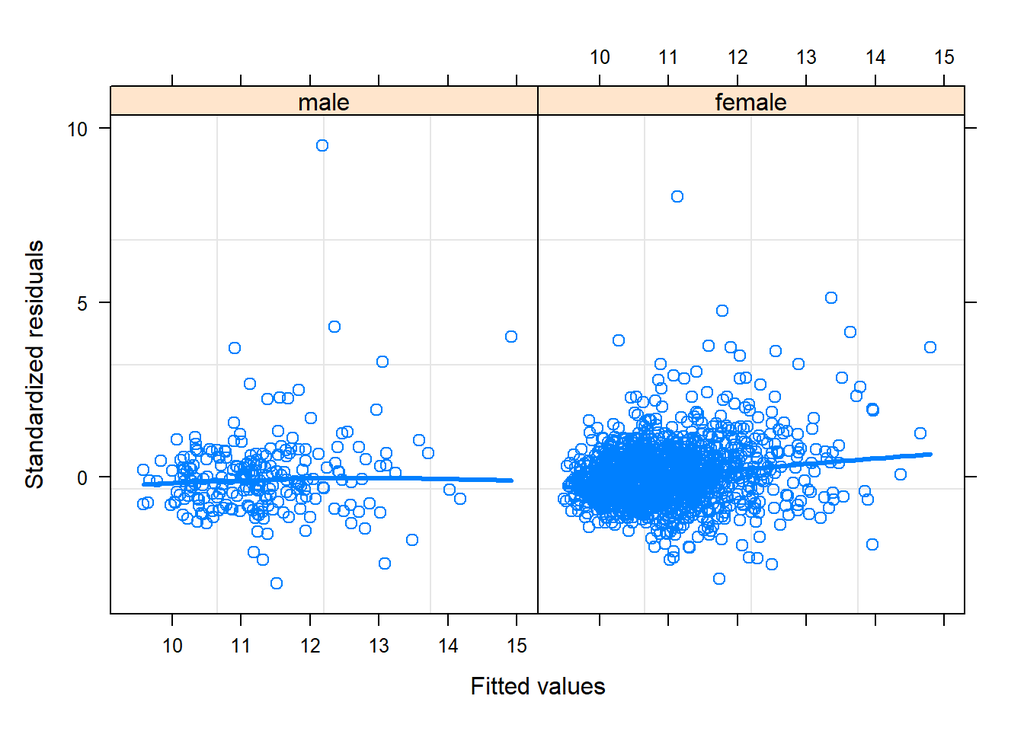

```r
plot(fm_3ML_noInt_LinAge, resid(., type = "p") ~ fitted(.) | sex,
     type = c("p", "smooth"), lwd = 3)
```

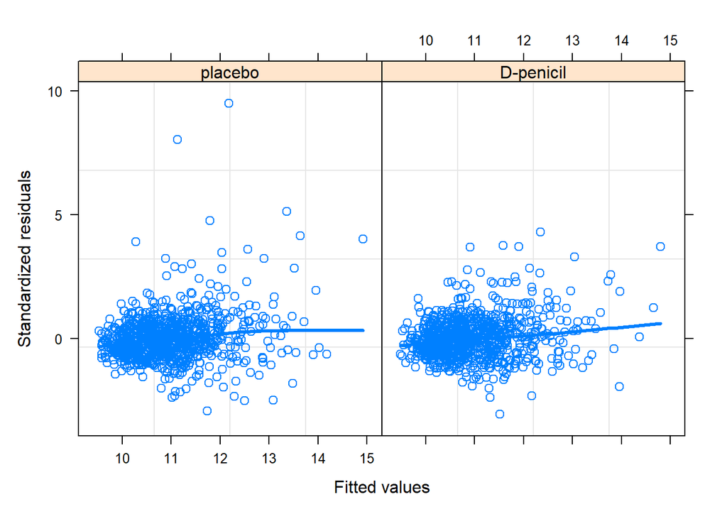

```r
plot(fm_3ML_noInt_LinAge, resid(., type = "p") ~ fitted(.) | drug,
     type = c("p", "smooth"), lwd = 3)
```

We continue by producing the same scatterplots but for the marginal residuals now:

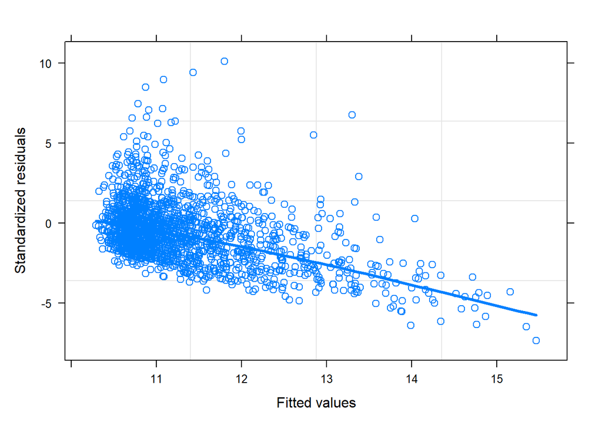

```r
plot(fm_3ML_noInt_LinAge, resid(., type = "p", level = 0) ~ fitted(., level = 0),
     type = c("p", "smooth"), lwd = 3)
```

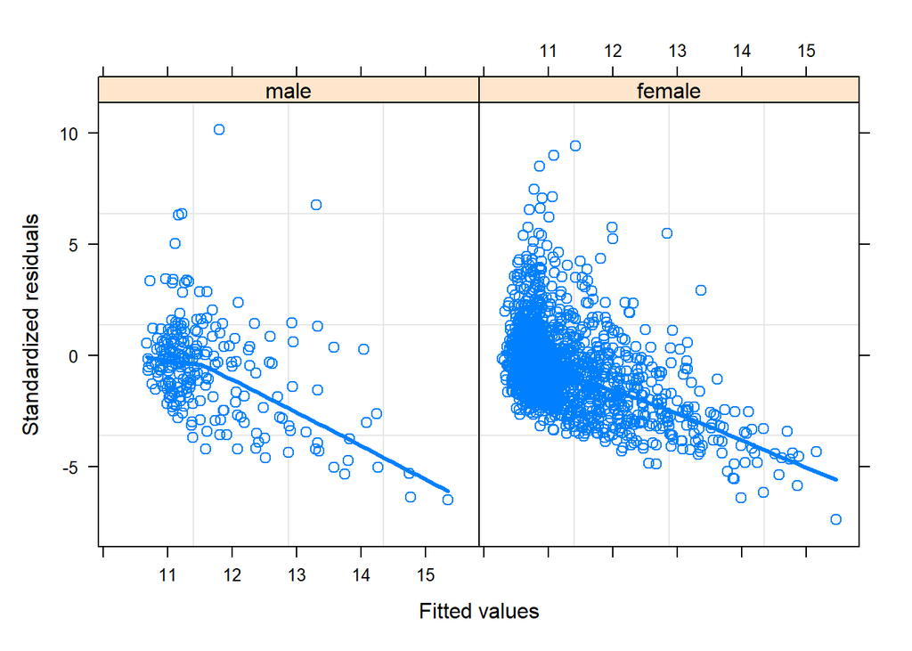

```r
plot(fm_3ML_noInt_LinAge, resid(., type = "p", level = 0) ~ fitted(., level = 0) | sex,
     type = c("p", "smooth"), lwd = 3)
```

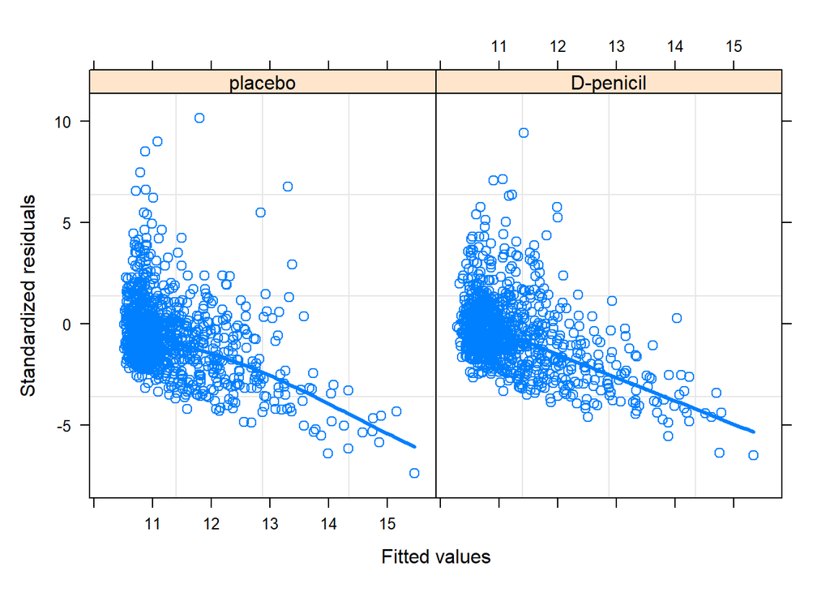

```r
plot(fm_3ML_noInt_LinAge, resid(., type = "p", level = 0) ~ fitted(., level = 0) | drug,
     type = c("p", "smooth"), lwd = 3)
```

Some observations:

- the conditional residuals show small faint signs of (remaining) heteroscedasticity, with more spread for larger fitted values. Though this behavior may be influenced by the couple outlying measurements that still remain in the dataset.
- the marginal residuals show a clear systematic trend, with (almost) only negative residuals for large fitted values. Even though this would seem as an alarming sign of model misfit, we should take it with a grain of salt. As we will see in Chapter 6, residual plots are susceptible to produce misleading conclusions due to incomplete data (i.e., dropout).